# Simulation Experiments

Andrea Brizzi

11/03/2021

## Settings

The objective of this html report is to document the results of each simulation. Here we define the settings of each simulation.

Time is measured in terms of days. Data is simulated according to a stochastic SEIR model as in Gnostic et al., and I modified Ed Baskervilles’ code. We assume the disease has mean exposure of 3 days and mean infectiousness of 4 days, implying an average generation time of 7 days/ 1 week

```r
gen_interval <- 7

simulations <- simulate_seir_stochastic(N = 100,
                                        arnaught = 3, gamma = 1/3, sigma = 1/4,
                                        Reporting_fraction = 1)
# In case we would like to simulate something that looks more like COVID, it would
# make more sense to take a look at daily incidence, and modify quite a few things.
```

We fit all different models assuming a gamma generation interval distribution with mean 6.5 days and standard deviation of 0.62 days, as in Flaxman et al.

```r
GTd <- R0::generation.time("gamma", c(6.5, 0.62))
```

## R estimates

Now that we only have one level of noise, we don’t have to go over a threefold loop.

In this experiment, I wanted to look at the effect of missed generations. To do so, I firstly simulate the data as in Megan’s paper, and then trim off them the data for 0, 1, 2 generation intervals. I fit the methods to each of these dataset and hopefully get some results later on.

```r
# list to store results from simulations
Sim_results <- list()


for (gen in 0:params$missed_gens){
    # Missed generations parameter

    results_gen <- list()


  # for each of the simulations
  for(j in 1:ncol(simulations$sims)){

    # data for fitting - simulation j with noise level i
    sim_j <- data.frame(day = 1:nrow(simulations[[1]]), cases=simulations[[1]][ ,j],
                         country=paste("sim", j, sep='_'))

    # start from first observations:
    sim_j <- filter(sim_j, cumsum(cases) > 0)

    # and cut out the first n_generations
    sim_j_gen <- sim_j %>% filter(day > gen_interval * gen)

    if(dim(sim_j_gen)[1] != 0){

      # fit & store results
      results_gen[[j]] <- fit_R0_seq(data=sim_j_gen,
                          mean_GT=6.5, sd_GT=0.62, GTd=GTd, GT_days=7,
                          methods = params$methods)

    } # might need an else

  }

    #store results from each missed_gen cut off
    Sim_results[[gen + 1]] <- results_gen

  }
```

At the moment I cannot seem to have EG_MLE working. WHY?

## Results

Now we want to compare if estimates obtained missing generations increased the value and/or uncertainty of the estimates of $R_0$.

To do, let us first detect all the simulations for which we are able to produce estimates for 0, 1 and 2 missed generations. \ A necessary (but not sufficient condition) is that the peak should be achieved after 2 + 2 weeks. We may be implicitly biasing our results by conditioning on the event that the peak is far enough.

```r
first_predictions <- data.frame()
indices = c()

# For each simulation
for (i in 1: length(Sim_results[[3]])){

  # if we are able to obtain estimates with 2 missed generations
  if (! is.null(Sim_results[[3]][[i]])){

    indices = c(indices, i)

    # attach first predictions when we don't miss any data
    tmp <- as.data.frame(Sim_results[[1]][[i]])
    tmp <- filter(tmp, `#GTofData` == 2)
    tmp$missed_gens <- 0
    first_predictions = rbind(first_predictions, tmp)

    # attach first predictions when we miss 1 week
    tmp <- as.data.frame(Sim_results[[2]][[i]])
    tmp <- filter(tmp, `#GTofData` == 2)
    tmp$missed_gens <- 1
    first_predictions = rbind(first_predictions, tmp)

    # attach first predictions when we miss 2 weeks
    tmp <- as.data.frame(Sim_results[[3]][[i]])
    tmp <- filter(tmp, `#GTofData` == 2)
    tmp$missed_gens <- 2
    first_predictions = rbind(first_predictions, tmp)

  }
}
rownames(first_predictions) <- NULL
```

```r
first_predictions$R0 <- as.numeric(first_predictions$R0)
first_predictions$Ndays <- as.numeric(first_predictions$Ndays)
sort(unique(first_predictions$Ndays))
```

```
## [1] 15 16 21 22 29
```

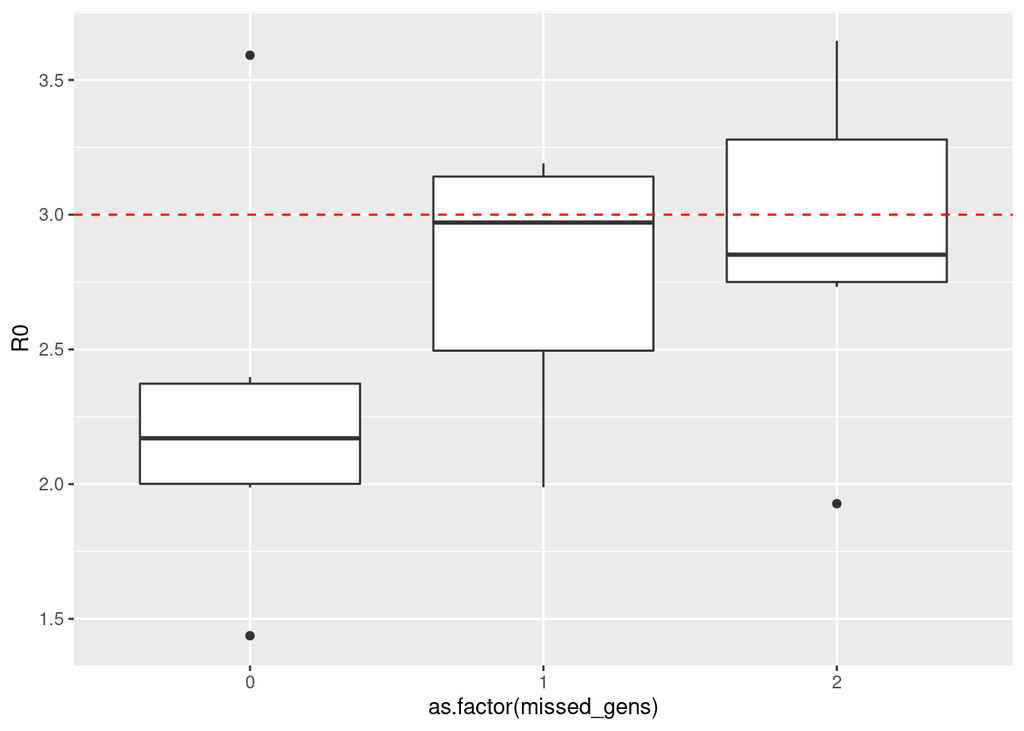

```r
df_eglin <- filter(first_predictions, method == "EG_Lin")
ggplot(df_eglin, aes(x = as.factor(missed_gens), y = R0)) +
  geom_boxplot() + geom_hline(yintercept = 3, colour = "red", linetype="dashed")
```

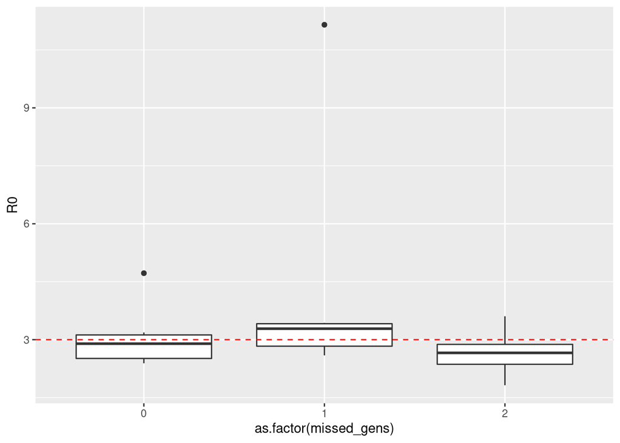

```r
df_egp <- filter(first_predictions, method == "EG_P")
ggplot(df_egp, aes(x = as.factor(missed_gens), y = R0)) +
  geom_boxplot() + geom_hline(yintercept = 3, colour = "red", linetype="dashed")
```

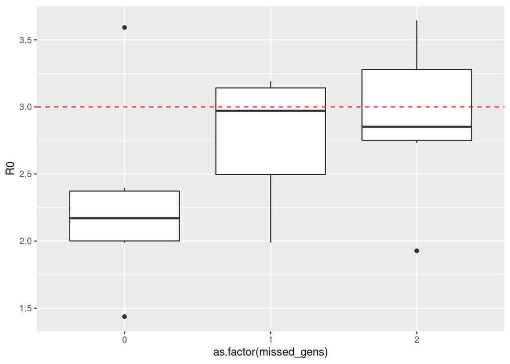

```r
df_EpiEstim <- filter(first_predictions, method == "EpiEstim")
ggplot(df_eglin, aes(x = as.factor(missed_gens), y = R0)) +
  geom_boxplot() + geom_hline(yintercept = 3, colour = "red", linetype="dashed")
```

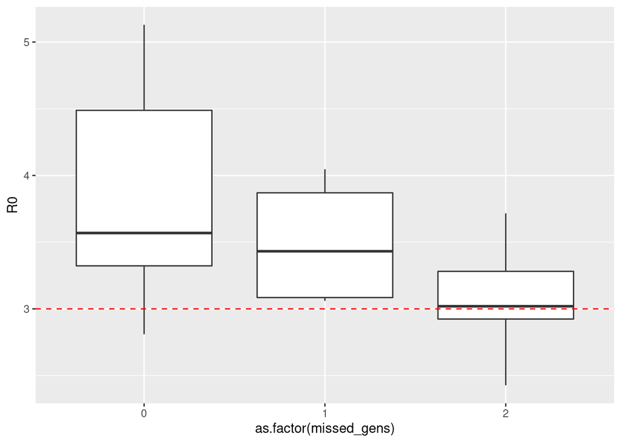

```r
df_WP <- filter(first_predictions, method == "WP")
ggplot(df_WP, aes(x = as.factor(missed_gens), y = R0)) +
  geom_boxplot() + geom_hline(yintercept = 3, colour = "red", linetype="dashed")
```

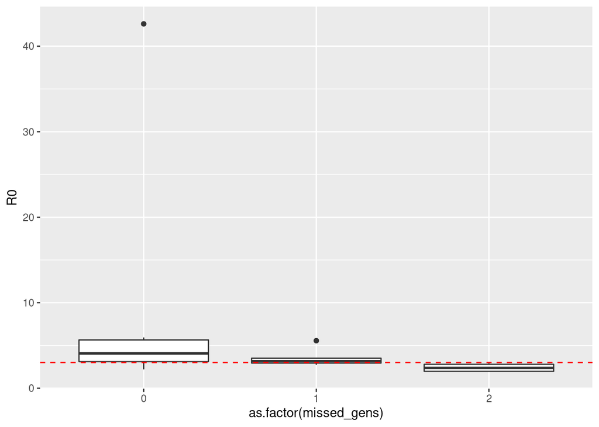

```r
df_WT <- filter(first_predictions, method == "WT")
ggplot(df_WT, aes(x = as.factor(missed_gens), y = R0)) +
  geom_boxplot() + geom_hline(yintercept = 3, colour = "red", linetype="dashed")
```

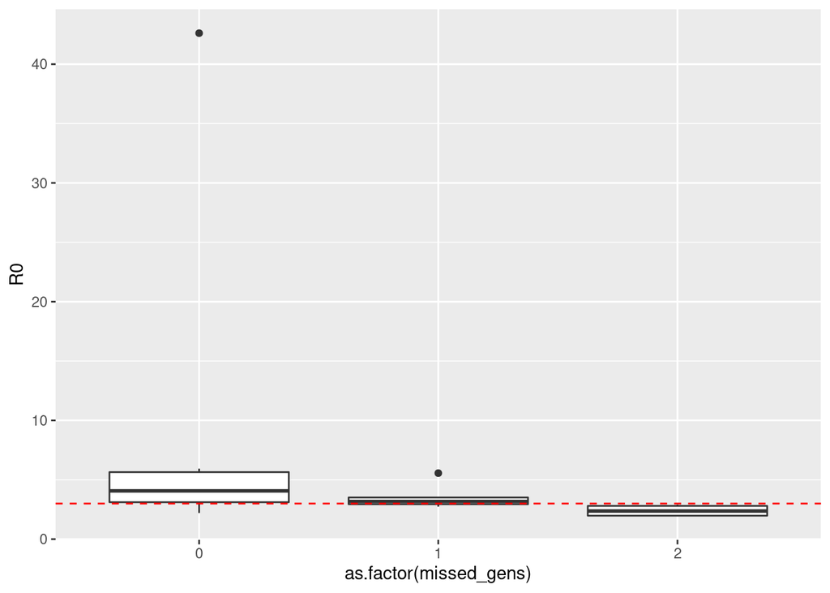

```r
df_BR <- filter(first_predictions, method == "BR")
ggplot(df_WT, aes(x = as.factor(missed_gens), y = R0)) +
  geom_boxplot() + geom_hline(yintercept = 3, colour = "red", linetype="dashed")
```

Every boxplot contains the same number of observations. But then why do we observe a decrease in variance as we miss more generations? (Maybe the more generations we have, the larger the total number of observations and so less uncertainty?)

```r
simulations$sims[,indices]
```

```
##     sim5 sim41 sim57 sim75 sim97 sim99
## 1      0     1     0     0     1     0
## 2      1     0     2     0     2     1
## 3      1     1     0     0     2     0
## 4      0     2     0     0     1     0
## 5      1     1     0     0     1     1
## 6      0     2     3     0     0     2
## 7      2     3     0     1     1     0
## 8      2     3     1     0     4     3
## 9      1     2     0     0     4     0
## 10     2     4     2     0     5     1
## 11     5     8     2     0     3     4
## 12     2     4     0     0     4     1
## 13     3    11     2     0     8     2
## 14     5    19     2     0    10     5
```

[output cut: 90 more lines]

## Just a little maths: Probability of immediate extinction of the disease

While trying to play around with the simulations, I noted that even with $R_0 = 2$, quite a few simulations did not produce any new observations This corresponds to a case in which the epidemic dies out immediately. I assume that this corresponds to the case in which there were no new infections (even though this is not true and it is a simplification to obtain a simple lower bound estimate). What is the probability of seeing this happen?
$$\begin{align}
\mathbb{P}[\text{immediate extinction}]
& =\mathbb{P}[\text{first } N_0 \text{ exponential events are recoveries}] \\
& \approx \left( \frac{\beta S_0 I_0}{N_0 \gamma I_0} \right)^{I_0} \approx (R_0 + 1)^{-I_0}
\end{align}$$
Where we used the definition $\beta = R_0 \gamma$. This makes sense as $R_0$ tends to $0$, $\infty$. Now, the number of initial infections is an integer sampled uniformly between 1 and 5. This means that for our simulations, the probability of immediate extinction can be estimated as:
$$p_{e} = \frac{1}{5} \sum_{i = 1}^5 r^{-i} = \frac{r}{5} \frac{1-r^5}{1-r}$$
where $r = (R_0 + 1)^-1$. For example, $r = 2$ would yield $p_e = 0.0996$. This does not seem to be correct. I obtain 22 percent empirically. For $r = 4$, we empirically obtain 4 out 1000, which still does not agree with the estimate of $p_e = 0.049984$…